# VaR via HMM(Hidden Markov Model)

Doynikov A.N.

2023-10-18

1. Прочитать данные своего варианта. Здесь выполняется 0-й вариант

```r
var <-0
data <- read.csv(fnames[var+1],header = T)
head(data)
```

```
##    X.DATE. X.CLOSE.
## 1 05/04/22   234.16
## 2 05/05/22   238.60
## 3 05/06/22   240.10
## 4 05/11/22   241.99
## 5 05/12/22   230.56
## 6 05/13/22   235.52
```

2. Для выдачи с календарными датами переводим данные в тип `time series’. В принципе это не обязательно делать.

```r
library(xts)
```

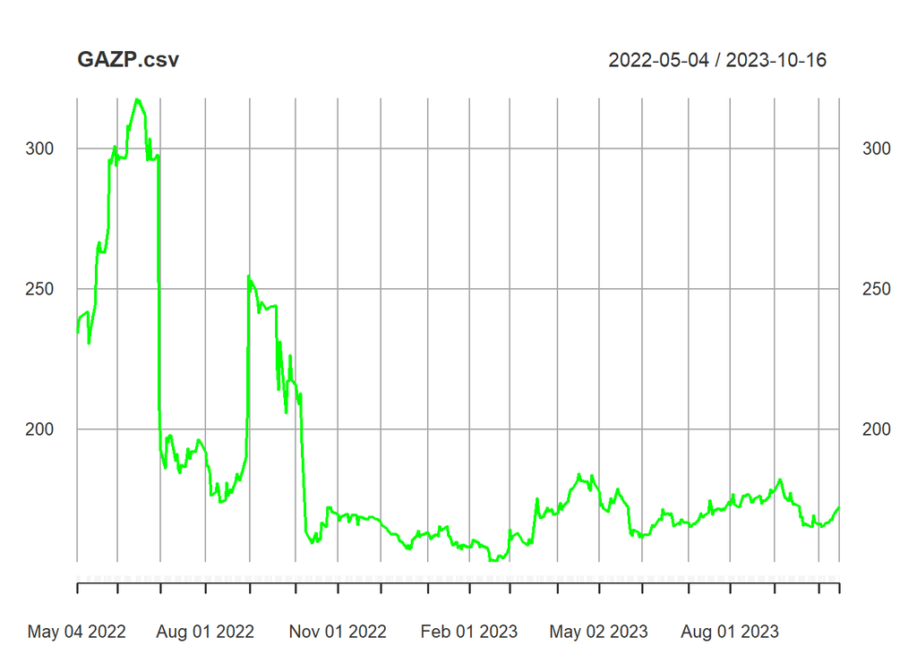

```r
    Dates <-as.Date(data[,1],"%m/%d/%y")
    histData <- data[,2]
    sample.xts <- as.xts(histData, order.by = Dates)
    plot(sample.xts,type = 'l',main = fnames[var+1],col= 'green' )
```

3. Вычислить ряд геометрических доходностей.
   $$r_t=\frac{S_t}{S_{t-1}}-1$$
   (Skipped Code)

```
## [1]  0.018961394  0.006286672  0.007871720 -0.047233357  0.021512838
## [6]  0.036854620
```

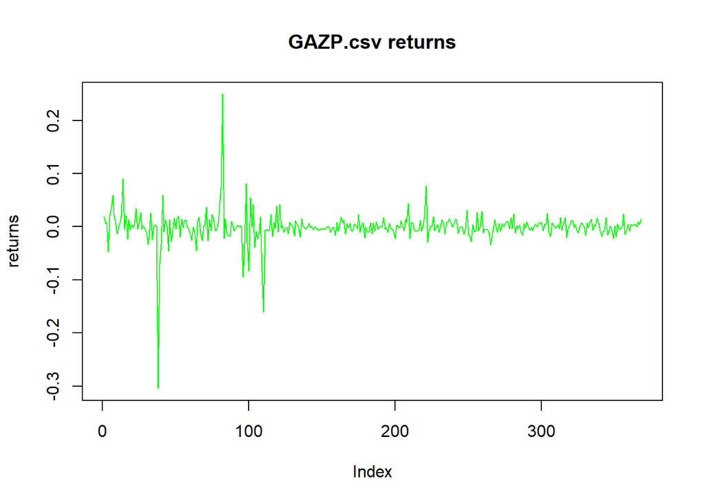

4. Создать HMM (Hidden Markov Model) объект для ряда доходностей и произвести оценку HMM модели для трех состояний

**Внимание!!!! Поставьте обязательно оператор `set.seed(100)` это упростит проверку. Но в случае Linux и Mac это скорее всего не поможет случайности результатов при каждом запуске кода. Чаще всего случайным образом меняется номер режима или состояния.**

```r
library(markovchain)
library(depmixS4)
set.seed(100)
```

(Skipped Code)

```
## converged at iteration 85 with logLik: 1009.094
```

5. Получите вероятности нахождения доходностей в некотором состоянии для каждой даты (Skipped Code)

```
##   state        S1         S2           S3
## 1     1 1.0000000 0.00000000 0.000000e+00
## 2     1 0.9221888 0.01028830 6.752285e-02
## 3     1 0.8825452 0.01016884 1.072859e-01
## 4     1 0.7966997 0.20328708 1.317919e-05
## 5     1 0.9339069 0.05475564 1.133742e-02
## 6     1 0.9310261 0.06872779 2.461016e-04
```

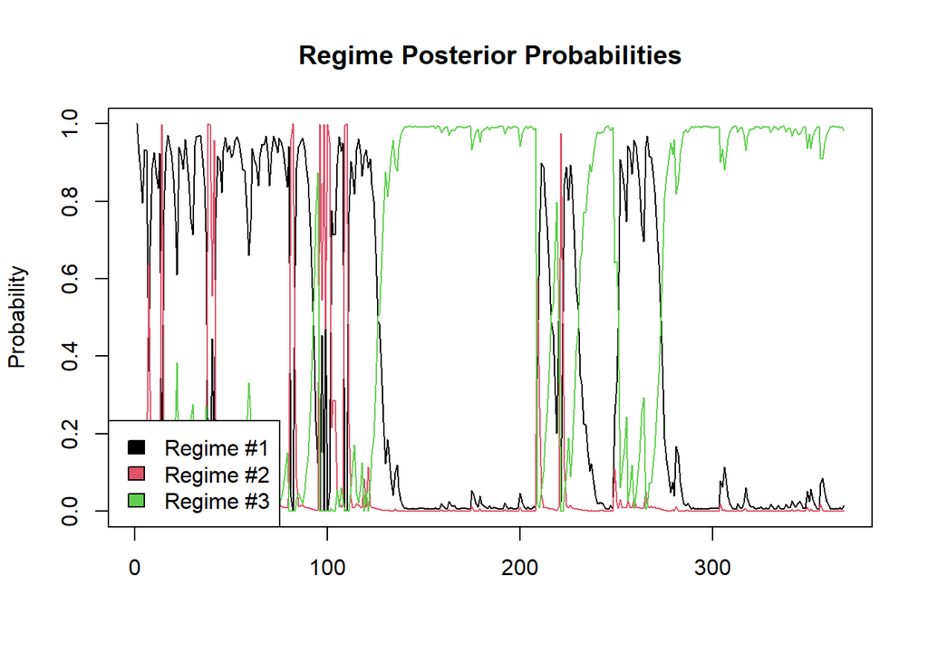

6. Получите номера состояния для доходности в каждой календарной дате. Результат помеcтите в переменную `posterior_state`. **Внимание может случаным образом меняться при каждом запучке кода** (Skipped Code)

```r
head(posterior_state, 10)
```

```
##  [1] 1 1 1 1 1 1 1 1 1 1
```

```r
tail(posterior_state, 10)
```

```
##  [1] 3 3 3 3 3 3 3 3 3 3
```

7. По вектору состояний оцените матрицу переходных вероятностей за один день. Результат поместите в переменную `trmatr`.

(Skipped Code)

```
##             1          2          3
## 1 0.934306569 0.04379562 0.02189781
## 2 0.375000000 0.62500000 0.00000000
## 3 0.009345794 0.00000000 0.99065421
```

8. Определите номер состояния в последний день наблюдений. Запомнить его в переменной `last_day_state`. (Skipped Code)

```
## [1] 3
```

9.Задайте начальное распределение с нахождением в состоянии `last_day_state`.

```r
initialState <- rep(0,times = 3)
initialState[last_day_state] <- 1
initialState
```

```
## [1] 0 0 1
```

10. Найдите индексы в ряде доходностей, когда ряд находится в состоянии `last_day_state`. Также определить ряд доходностей для этого состояния. (Skipped Code)

```r
    head(ind_state,10)
```

```
##  [1] 122 123 124 125 126 127 128 129 130 131
```

```r
    tail(ind_state,10)
```

```
##  [1] 359 360 361 362 363 364 365 366 367 368
```

```r
    head(state_rates,10)
```

```
##  [1] -0.0023204548  0.0028491685 -0.0100887111 -0.0026943127 -0.0020555588
##  [6] -0.0129472693  0.0084664918  0.0041977060  0.0007065057 -0.0168853327
```

```r
    tail(state_rates,10)
```

```
##  [1]  0.0040342004 -0.0080959520  0.0039903265  0.0031916175  0.0028212978
##  [6]  0.0058062971 -0.0008331846  0.0095896122  0.0041297935  0.0146298472
```

11. Создайте объект типа “markovchain” (Skipped Code)

```
## GAZP.csv
##  A  3 - dimensional discrete Markov Chain defined by the following states:
##  1, 2, 3
##  The transition matrix  (by rows)  is defined as follows:
##             1          2          3
## 1 0.934306569 0.04379562 0.02189781
## 2 0.375000000 0.62500000 0.00000000
## 3 0.009345794 0.00000000 0.99065421
```

12. Найдите вероятностное распределение состояния акции через 3 дня. Результат поместите в переменную `after3Days`.

(Skipped Code)

```
##               1           2         3
## [1,] 0.02613577 0.001043711 0.9728205
```

13. Найдите стационарное распределение состояния акции. Результат поместите в переменную `steady_states`.

(Skipped Code)

```
##              1          2         3
## [1,] 0.2890295 0.03375527 0.6772152
```

14. Вычислите исторический 95% VaR (Value at Risk) для доходностей в последний день наблюдений при условии, что состояние в этот день равно `last_day_state`. Вспоминая весенний семестр, это можно сделать двумя путями:
- Через вычисление выборочного квантиля уровня 0.05 = 1-0.95
- Вызвать соответствующую функцию `VaR(state_rates,p=.95,method="historical"))` из библитотеки library(PerformanceAnalytics)

Результаты должны совпасть.

```r
    (VaR_hist <- quantile(state_rates,0.05))
```

```
##          5%
## -0.01565927
```

```r
     library(PerformanceAnalytics)
```

```r
    (VaR_hist <- VaR(state_rates,p=.95, method="historical"))
```

```
##            [,1]
## VaR -0.01565927
```

Результат запомните в переменной `VaR_hist`.

15. Вычислите исторический VaR для доходностей за весь период наблюдений вне зависимости от состояния (Skipped Code)

```
##          5%
## -0.02642833
```

Результат запомните в переменной `VaR_all_returns`.

16. Создайте переменную `var` c номером Вашего варианта.
17. Создайте объект типа `list` со следующими именами полей. и сохраните его в некоторый файл.

```r
result <- list(
    variant = var, # номер Вашего варианта
    posterior_state = posterior_state,
    trmatr = trmatr, #матрица переходных вероятностей
    after3Days = after3Days,
    steady_states = steady_states,
    VaR_hist = VaR_hist,
    VaR_all_returns=VaR_all_returns
)

saveRDS(result, paste0('result_',var,'.rds'))
```

18. Запустите приложение по указанной ссылке, загрузите в него полученный результат и смотрите результат. https://shiny.ilykei.com/ANDoynikov//Test416/Test8

Попыток всего 10, после достижения которых результат не улучшается.

## Варианты

1,14 ‘SBER.csv’, Сбербанк

2,15 ‘SBERP.csv’,Сбербанк превилегированные

3,16 ‘LKOH.csv’, Лукойл

4,17 ‘AFLT.csv’, Аэрофлот

5,18 ‘VTB.csv’, ВТБ

6,19 ‘MGNT.csv’, Магнит

7,20 ‘PLZL.csv’, Полюс-золото

8,21 ‘ROSN.csv’, Рос. нефть

9,22 ‘RTKM.csv’, Ростелеком

10,23 ‘CHMF.csv’, Север сталь

11,24 ‘SNGS.csv’, Сургут нефть газ

12,25 ‘TATN.csv’, Татнефть

13,26 ‘HYDR.csv’ Рос Гидро